# Data Science Challenge - First Part

Rui Romanini

10 de novembro de 2016

## Description

In this challenge, suppose we are looking to do social network analysis for prospective customers. We want to extract from their social network a metric called “closeness centrality”.

Centrality metrics try to approximate a measure of influence of an individual wiisthin a social network. The distance between any two vertices is their shortest path. The *farness* of a given vertex *v* is the sum of all distances from each vertex to *v*. Finally, the *closeness* of a vertex *v* is the inverse of the *farness*.

The first part of the challenge is to rank the vertices in a given graph by their *closeness*. The graph is provided in the attached file; each line of the file consists of two vertex names separated by a single space, representing an edge between those two nodes.

## The environment

It’s important to pay atention to the environment, to make sure about reproducibility.

This code was produced using R version 3.3.1 and R Studio version 0.99.489

The Operational System it’s Windows 10 Home

## Dependencies

In this step, we install de dependencies.

```r
if(!require(igraph)){
  install.packages("igraph", repos ="http://cran.us.r-project.org")
  library(igraph)
}
```

## Getting data

In this step, the edges.dat file it’s downloaded from the GitHub Repository and the vertices are read using read.csv function. Blank space used as separator and there is no Header in this file. Only two columns representing the vertices and the edge.

```r
#Download do arquivo contendo os links e leitura do arquivo texto
destfile="./edges.dat"
fileURL = "https://raw.githubusercontent.com/rromanini/DesafioSemantix/master/PartI/edges.dat";
download.file(fileURL,destfile=destfile,method="auto")
vertices <- read.csv("./edges.dat" ,sep = " ",header = FALSE)
```

## Exploring and cleaning data

In this step I checked the data looking for strange values, patterns or missing values.

No problems was detected.

```r
summary(vertices)
```

```
##        V1              V2
##  Min.   : 0.00   Min.   : 0.00
##  1st Qu.:26.00   1st Qu.:26.00
##  Median :50.00   Median :51.00
##  Mean   :49.81   Mean   :50.23
##  3rd Qu.:75.00   3rd Qu.:75.00
##  Max.   :99.00   Max.   :99.00
```

“Missing values” in the list

```r
length(which(is.na(vertices) == TRUE))
```

```
## [1] 0
```

## Creating the graph object

Now we can build the graph with the vertices and edges. I choose to keep the directions.

```r
net <-graph_from_data_frame(d=vertices,directed = T)
```

## Creating the plot

Now we can build the plot showing the nodes and connections. I did generate an export of the plot because there is a great number of vertices and the plot visibility it’s bad.

The export is in the repository, on Part I folder.

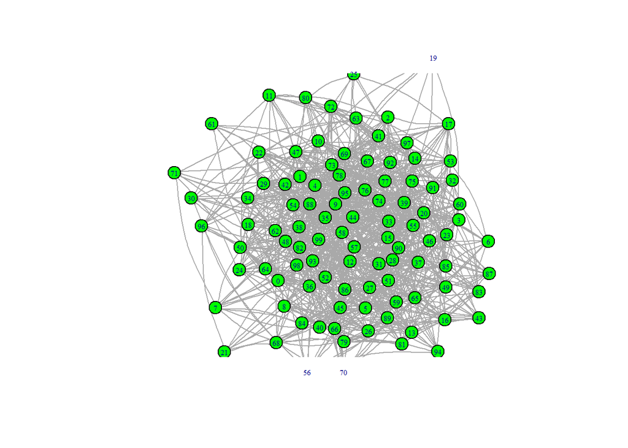

```r
l <- layout_with_fr(net)
l <- norm_coords(l, ymin=-1, ymax=1, xmin=-1, xmax=1)

plot(net,edge.arrow.size=.05,vertex.size=10,
     edge.curved=0.2,
     vertex.frame.color="black",
     vertex.color="green",
     vertex.label.cex=0.5,rescale=F, layout=l*1.2)
```

## Getting the Closeness

Now we can build the closeness

Cloness centrality measures how many steps is required to access every other vertex from a given vertex.

The function used here return a numeric vector with the closeness values of all the vertices, ordered by the closeness score

```r
closeness_matrix <- as.matrix(closeness(net, mode="out"))
closeness_matrix <- as.matrix(closeness_matrix[order(closeness_matrix[,1],decreasing = TRUE),])

#Add column name
colnames(closeness_matrix) <- c("Closeness")

closeness_matrix
```

```
##      Closeness
## 44 0.005208333
## 88 0.005050505
## 20 0.005050505
## 74 0.005025126
## 33 0.004950495
## 4  0.004901961
## 28 0.004901961
## 35 0.004878049
## 89 0.004878049
## 5  0.004854369
## 1  0.004854369
## 41 0.004830918
## 78 0.004807692
## 75 0.004807692
```

[output cut: 86 more lines]

## Conclusion

In this challenge I used the igraph library to generate the network nodes.

I sent the graph file (edges.dat) to the GIT HUB repository and the file it’s dowloaded during the analyzes. I did this to make sure that the code is reproducible.

There is a step to check if there is invalid values in the text file.

After that, I built the node network using igraph and after that I check the closeness of this vertices.

The closeness’s values would be bigger if all nodes were connected but I observed about 8 ~ 12 connections each.